# Predicting House Prices for King County

# Introduction

The goal of this project is to predict house prices for King County. We will build models used for prediction of house prices based on the King County house sales dataset, which includes houses sold between May 2014 and May 2015. During the submission time, we evaluated multiple data sets, but, after the final analysis we settled on the Kings County dataset. This dataset includes over 20k observations and the variables are information on the house sold such as square footage, year built, year renovated, price sold and so on. This dataset can be found on the [Kaggle Website](https://www.kaggle.com/harlfoxem/housesalesprediction) and information on it can be found [here](https://geodacenter.github.io/data-and-lab/KingCounty-HouseSales2015/).

### Description of the dataset

- id - Unique ID for each home sold
- date - Date of the home sale
- price - Price of each home sold
- bedrooms - Number of bedrooms
- bathrooms - Number of bathrooms, where .5 accounts for a room with a toilet but no shower
- sqft_living - Square footage of the apartments interior living space
- sqft_lot - Square footage of the land space
- floors - Number of floors
- waterfront - A dummy variable for whether the apartment was overlooking the waterfront or not
- view - An index from 0 to 4 of how good the view of the property was
- condition - An index from 1 to 5 on the condition of the apartment,
- grade - An index from 1 to 13, where 1-3 falls short of building construction and design, 7 has an average level of construction and design, and 11-13 have a high quality level of construction and design.
- sqft_above - The square footage of the interior housing space that is above ground level
- sqft_basement - The square footage of the interior housing space that is below ground level
- yr_built - The year the house was initially built
- yr_renovated - The year of the house’s last renovation
- zipcode - What zipcode area the house is in
- lat - Lattitude
- long - Longitude
- sqft_living15 - The square footage of interior housing living space for the nearest 15 neighbors
- sqft_lot15 - The square footage of the land lots of the nearest 15 neighbors

# Methods

```r
## Load useful libraries
library(ggplot2)
library(knitr)
library(faraway)
library(dplyr)
library(GGally)
library(MASS)
```

## Data Clean-Up

To start, we must first clean up the data set, such as by removing `NA` values and coercing certain variables to be factors, such as `waterfront`.

```r
## Loading data set
kc_dataset = read.csv("kc_house_data.csv")

## Inspect Data set
str(kc_dataset)
```

```
## 'data.frame':    21613 obs. of  21 variables:
##  $ id           : num  7.13e+09 6.41e+09 5.63e+09 2.49e+09 1.95e+09 ...
##  $ date         : chr  "20141013T000000" "20141209T000000" "20150225T000000" "20141209T000000" ...
##  $ price        : num  221900 538000 180000 604000 510000 ...
##  $ bedrooms     : int  3 3 2 4 3 4 3 3 3 3 ...
##  $ bathrooms    : num  1 2.25 1 3 2 4.5 2.25 1.5 1 2.5 ...
##  $ sqft_living  : int  1180 2570 770 1960 1680 5420 1715 1060 1780 1890 ...
##  $ sqft_lot     : int  5650 7242 10000 5000 8080 101930 6819 9711 7470 6560 ...
##  $ floors       : num  1 2 1 1 1 1 2 1 1 2 ...
##  $ waterfront   : int  0 0 0 0 0 0 0 0 0 0 ...
##  $ view         : int  0 0 0 0 0 0 0 0 0 0 ...
##  $ condition    : int  3 3 3 5 3 3 3 3 3 3 ...
##  $ grade        : int  7 7 6 7 8 11 7 7 7 7 ...
##  $ sqft_above   : int  1180 2170 770 1050 1680 3890 1715 1060 1050 1890 ...
##  $ sqft_basement: int  0 400 0 910 0 1530 0 0 730 0 ...
##  $ yr_built     : int  1955 1951 1933 1965 1987 2001 1995 1963 1960 2003 ...
##  $ yr_renovated : int  0 1991 0 0 0 0 0 0 0 0 ...
##  $ zipcode      : int  98178 98125 98028 98136 98074 98053 98003 98198 98146 98038 ...
##  $ lat          : num  47.5 47.7 47.7 47.5 47.6 ...
##  $ long         : num  -122 -122 -122 -122 -122 ...
##  $ sqft_living15: int  1340 1690 2720 1360 1800 4760 2238 1650 1780 2390 ...
##  $ sqft_lot15   : int  5650 7639 8062 5000 7503 101930 6819 9711 8113 7570 ...
```

```r
## Checking for NAs
(contains_na = kc_dataset[!complete.cases(kc_dataset),])
```

```
##  [1] id            date          price         bedrooms      bathrooms
##  [6] sqft_living   sqft_lot      floors        waterfront    view
## [11] condition     grade         sqft_above    sqft_basement yr_built
## [16] yr_renovated  zipcode       lat           long          sqft_living15
## [21] sqft_lot15
## <0 rows> (or 0-length row.names)
```

```r
sum(is.na(kc_dataset))
```

```
## [1] 0
```

```r
## Changing the waterfront variable to be view and no-view instead of 1 and 0
kc_dataset$waterfront = ifelse(kc_dataset$waterfront == 0, "no-view", "view")

## Coerce variables to be factor
kc_dataset$waterfront = as.factor(kc_dataset$waterfront)
kc_dataset$zipcode = as.factor(kc_dataset$zipcode)

## Removing two variables that we consider to not be useful.
kc_dataset = subset(kc_dataset, select = -c(id, date))
```

## Data Exploration

In this section we will try to investigate insights on this dataset. Hopefully what we discover here will come in handy when building and choosing the best model.

```r
summary(kc_dataset)
```

```
##      price            bedrooms        bathrooms      sqft_living
##  Min.   :  75000   Min.   : 0.000   Min.   :0.000   Min.   :  290
##  1st Qu.: 321950   1st Qu.: 3.000   1st Qu.:1.750   1st Qu.: 1427
##  Median : 450000   Median : 3.000   Median :2.250   Median : 1910
##  Mean   : 540088   Mean   : 3.371   Mean   :2.115   Mean   : 2080
##  3rd Qu.: 645000   3rd Qu.: 4.000   3rd Qu.:2.500   3rd Qu.: 2550
##  Max.   :7700000   Max.   :33.000   Max.   :8.000   Max.   :13540
##
##     sqft_lot           floors        waterfront         view
##  Min.   :    520   Min.   :1.000   no-view:21450   Min.   :0.0000
##  1st Qu.:   5040   1st Qu.:1.000   view   :  163   1st Qu.:0.0000
##  Median :   7618   Median :1.500                   Median :0.0000
##  Mean   :  15107   Mean   :1.494                   Mean   :0.2343
##  3rd Qu.:  10688   3rd Qu.:2.000                   3rd Qu.:0.0000
##  Max.   :1651359   Max.   :3.500                   Max.   :4.0000
##
##    condition         grade          sqft_above   sqft_basement
##  Min.   :1.000   Min.   : 1.000   Min.   : 290   Min.   :   0.0
##  1st Qu.:3.000   1st Qu.: 7.000   1st Qu.:1190   1st Qu.:   0.0
##  Median :3.000   Median : 7.000   Median :1560   Median :   0.0
##  Mean   :3.409   Mean   : 7.657   Mean   :1788   Mean   : 291.5
##  3rd Qu.:4.000   3rd Qu.: 8.000   3rd Qu.:2210   3rd Qu.: 560.0
##  Max.   :5.000   Max.   :13.000   Max.   :9410   Max.   :4820.0
##
##     yr_built     yr_renovated       zipcode           lat
##  Min.   :1900   Min.   :   0.0   98103  :  602   Min.   :47.16
##  1st Qu.:1951   1st Qu.:   0.0   98038  :  590   1st Qu.:47.47
##  Median :1975   Median :   0.0   98115  :  583   Median :47.57
##  Mean   :1971   Mean   :  84.4   98052  :  574   Mean   :47.56
##  3rd Qu.:1997   3rd Qu.:   0.0   98117  :  553   3rd Qu.:47.68
##  Max.   :2015   Max.   :2015.0   98042  :  548   Max.   :47.78
##                                  (Other):18163
##       long        sqft_living15    sqft_lot15
##  Min.   :-122.5   Min.   : 399   Min.   :   651
##  1st Qu.:-122.3   1st Qu.:1490   1st Qu.:  5100
##  Median :-122.2   Median :1840   Median :  7620
##  Mean   :-122.2   Mean   :1987   Mean   : 12768
##  3rd Qu.:-122.1   3rd Qu.:2360   3rd Qu.: 10083
##  Max.   :-121.3   Max.   :6210   Max.   :871200
##
```

We will start by simply plotting the the house prices distribution.

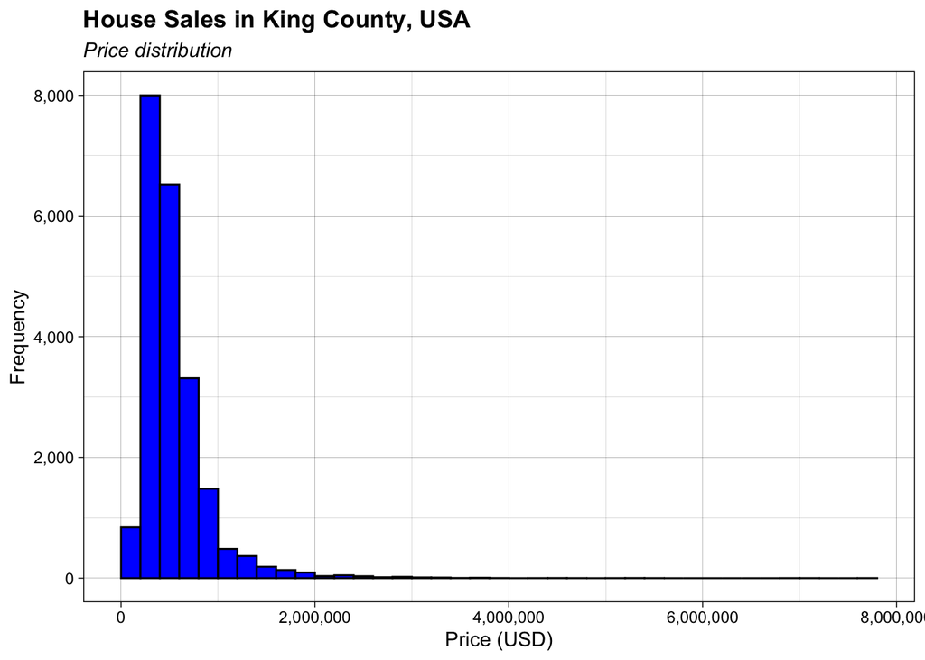

```r
ggplot(kc_dataset, aes(x = price)) +
geom_histogram(col = 'black', fill = 'blue', binwidth = 200000, center = 100000) +
theme_linedraw() +
theme(plot.title = element_text(hjust = 0, face = 'bold',color = 'black'), #title settings
      plot.subtitle = element_text(face = "italic")) + #subtitle settings
labs(x = 'Price (USD)', y = 'Frequency', title = "House Sales in King County, USA",
     subtitle = "Price distribution") + #name subtitle
scale_y_continuous(labels = scales::comma, limits = c(0,8000), breaks = c(0,2000,4000,6000,8000)) +
scale_x_continuous(labels = scales::comma) #prevent scientific number in x-axis
```

From distribution chart above, we know that price range of $200,000 - $600,000 has higher frequency than the other prices.

Now let’s plot the living area, and plot area with the information of the grade and the condition shown as well. This should provide us some insights.

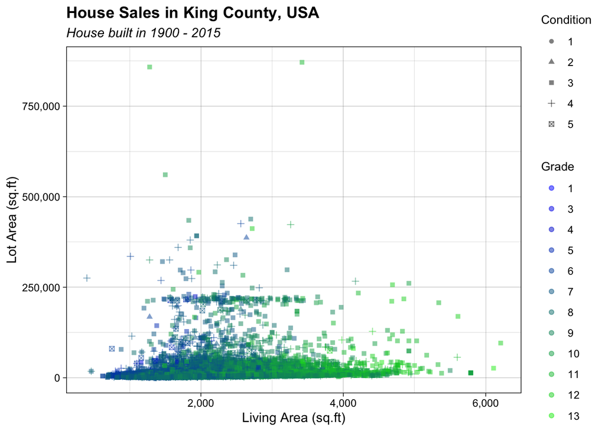

```r
rbPal <- colorRampPalette(c('blue','green'))
rbPal2 <- colorRampPalette(c('black','red'))
colors1 <- rbPal(13)
colors2 <- rbPal2(13)

ggplot(kc_dataset, aes(x = sqft_living15, y = sqft_lot15)) +
geom_jitter(alpha = 0.5, aes(shape = as.factor(condition), color = as.factor(grade))) +
scale_color_manual(values = colors1) +
theme_linedraw() +
theme(legend.title = element_text(size=10),
      plot.title = element_text(hjust = 0, face = 'bold',color = 'black'),
      plot.subtitle = element_text(face = "italic")) +
labs(x = 'Living Area (sq.ft)', y = 'Lot Area (sq.ft)', title = "House Sales in King County, USA",
     subtitle = "House built in 1900 - 2015") +
guides(color = guide_legend(title = "Grade"),
       shape = guide_legend(title = 'Condition')) +
scale_x_continuous(labels = scales::comma) +
scale_y_continuous(labels = scales::comma)
```

For a better sense of the distribution of some of the numeric variables, we looked at histograms for each of them.

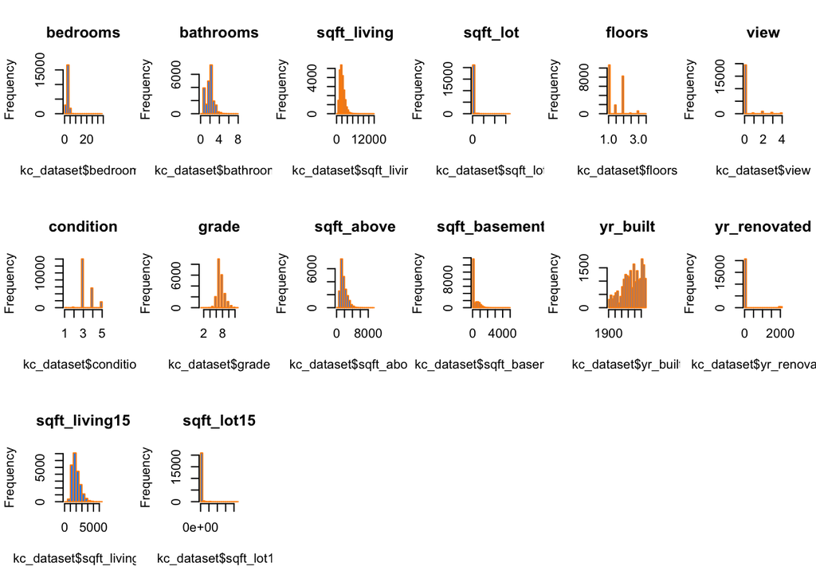

```r
par(mfrow = c(3, 6))
hist(kc_dataset$bedrooms, breaks = 20, main = "bedrooms", border="darkorange", col="dodgerblue")
hist(kc_dataset$bathrooms, breaks = 20, main = "bathrooms", border="darkorange", col="dodgerblue")
hist(kc_dataset$sqft_living, breaks = 20, main = "sqft_living", border="darkorange", col="dodgerblue")
hist(kc_dataset$sqft_lot, breaks = 20, main = "sqft_lot", border="darkorange", col="dodgerblue")
hist(kc_dataset$floors, breaks = 20, main = "floors", border="darkorange", col="dodgerblue")
hist(kc_dataset$view, breaks = 20, main = "view", border="darkorange", col="dodgerblue")
hist(kc_dataset$condition, breaks = 20, main = "condition", border="darkorange", col="dodgerblue")
hist(kc_dataset$grade, breaks = 20, main = "grade", border="darkorange", col="dodgerblue")
hist(kc_dataset$sqft_above, breaks = 20, main = "sqft_above", border="darkorange", col="dodgerblue")
hist(kc_dataset$sqft_basement, breaks = 20, main = "sqft_basement", border="darkorange", col="dodgerblue")
hist(kc_dataset$yr_built, breaks = 20, main = "yr_built", border="darkorange", col="dodgerblue")
hist(kc_dataset$yr_renovated, breaks = 20, main = "yr_renovated", border="darkorange", col="dodgerblue")
hist(kc_dataset$sqft_living15, breaks = 20, main = "sqft_living15", border="darkorange", col="dodgerblue")
hist(kc_dataset$sqft_lot15, breaks = 20, main = "sqft_lot15", border="darkorange", col="dodgerblue")
```

## Varible Correlation & Collinearity

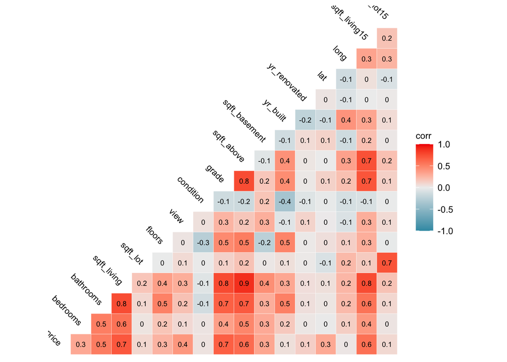

```r
ggcorr(kc_dataset, name = "corr", label = TRUE, hjust = 1, label_size = 2.5, angle = -45, size = 3)
```

One other thing that sticks out is the `sqft_lot` and `sqft_living` seems to related to `sqft_lot15` and `sqft_living15` respectively. This also makes sense, since the house size and the lot size will usually follow the neighborhood house size trend. We will be dealing with collinearity issues during variable selection.

### Tranformations Identification

Now, before we start modeling, we look at the pairs plots to see if any of the parameters are an obvious choice for transformations

For the purpose of being able to see the plots clearly, we do two things for the visual of the pair plot: -Filter out the columns that have 35 or less discrete values, since they will probably not be candidates for transformations -Focus only on numeric columns

```r
predictor_unique_values = 35
clean_df_numeric_only <- kc_dataset[,sapply(kc_dataset, is.numeric)]
predictor_to_remove_for_plot <- c()
removal_counter=1
for(pred in colnames(clean_df_numeric_only)) {
  k <- length(unique(clean_df_numeric_only[,pred])<predictor_unique_values)
  if(k<predictor_unique_values){
    predictor_to_remove_for_plot[removal_counter] <- pred
    removal_counter <- removal_counter+1
  }
}
# as zipcode needs to be used as a categorical variable.
predictor_to_remove_for_plot[removal_counter]<-"zipcode"
predictor_to_remove_for_plot
```

```
## [1] "bedrooms"  "bathrooms" "floors"    "view"      "condition" "grade"
## [7] "zipcode"
```

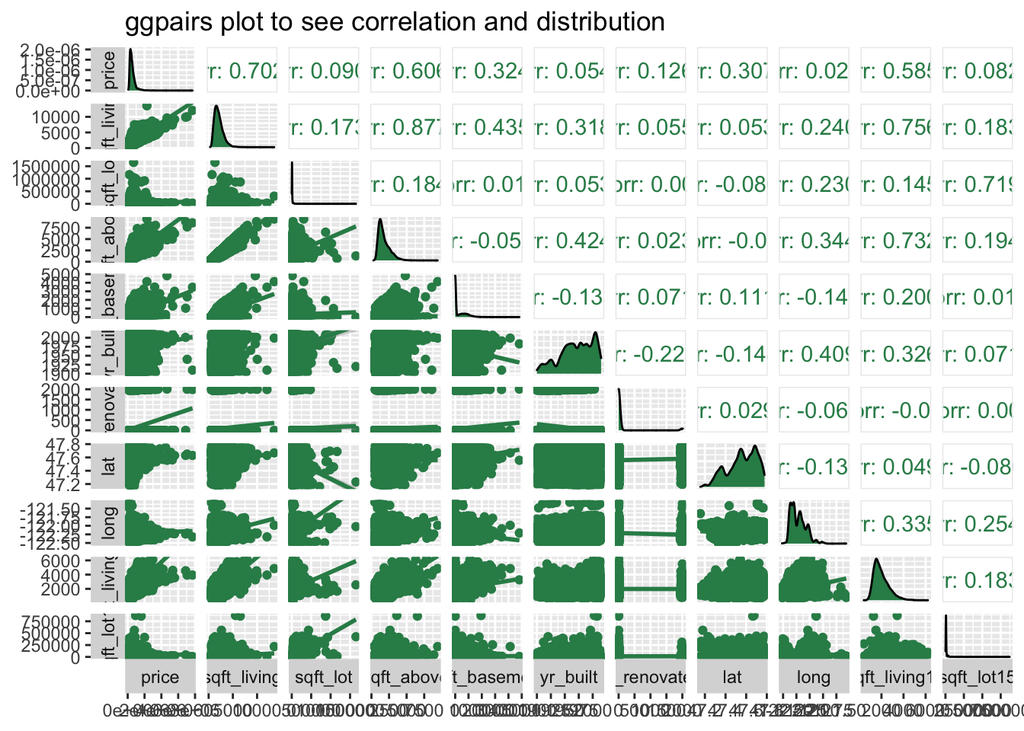

```r
plot_predictors <- colnames(clean_df_numeric_only)[!(colnames(clean_df_numeric_only) %in% predictor_to_remove_for_plot)]
housing_data_clean_df_for_plot <- subset(clean_df_numeric_only, select = as.vector(eval(plot_predictors)))

ggpairs( housing_data_clean_df_for_plot, ggplot2::aes(color=I("sea green")), title = "ggpairs plot to see correlation and distribution", lower = list(continuous = wrap("smooth")), axisLabels = "show", switch = "both")
```

We make the following observations from the plot: Potential for transformations `price`, `sqft_living` , `sqft_lot`, `sqft_basement`, `yr_built`, `lat`, `long`

## Model Building

### Variable Selection

Let’s start by building a model with the predictors we found to be the most correlated to price and compare it with a full model.

```r
## Split data into train and test
set.seed(2021)
kc_trn_idx  = sample(nrow(kc_dataset), size = trunc(0.80 * nrow(kc_dataset)))
kc_train_data = kc_dataset[kc_trn_idx, ]
kc_test_data = kc_dataset[-kc_trn_idx, ]

## Fit the full model
full_model = lm(price ~., data = kc_train_data)

## Fit the model with only the good predictors we found earlier
good_preds_model = lm(price ~ bathrooms + sqft_living + grade + sqft_above + sqft_living15, data = kc_train_data)

summary(good_preds_model)$adj.r.squared
```

```
## [1] 0.5459385
```

```r
anova(good_preds_model, full_model)$"Pr(>F)"[2] < 0.10
```

```
## [1] TRUE
```

At $ = 0.10 $, we reject the null hypothesis. This means we prefer the larger model with all the variables. So clearly we are missing some more predictors.

Let’s check the variance inflation factor to find the highly correlated predictors.

```r
vif(full_model)
```

```
##       bedrooms      bathrooms    sqft_living       sqft_lot         floors
##   1.684958e+00   3.411171e+00   8.874564e+00   2.100441e+00   2.461390e+00
## waterfrontview           view      condition          grade     sqft_above
##   1.254925e+00   1.509339e+00   1.316821e+00   3.834899e+00   7.537722e+00
##  sqft_basement       yr_built   yr_renovated   zipcode98002   zipcode98003
##   6.932627e+02   6.371301e-03   2.764254e+07   1.375417e+00   5.581871e+00
##   zipcode98004   zipcode98005   zipcode98006   zipcode98007   zipcode98008
##   7.549006e+00   2.918849e+00   1.317495e+01   3.310989e+00   5.184843e+00
##   zipcode98010   zipcode98011   zipcode98014   zipcode98019   zipcode98022
##   4.051615e+00   9.260776e+00   5.639797e+00   2.701998e+00   1.262909e+00
##   zipcode98023   zipcode98024   zipcode98027   zipcode98028   zipcode98029
##   1.977834e+01   1.320527e+00   1.541149e+01   6.185661e+00   2.528682e+00
##   zipcode98030   zipcode98031   zipcode98032   zipcode98033   zipcode98034
##   2.186341e+00   2.987665e+00   3.562417e+00   1.391520e+01   5.272210e+00
##   zipcode98038   zipcode98039   zipcode98040   zipcode98042   zipcode98045
##   2.244712e+01   8.583609e-01   2.071919e+00   1.899902e+01   6.208792e+00
##   zipcode98052   zipcode98053   zipcode98055   zipcode98056   zipcode98058
##   1.979656e+01   4.059782e+00   3.242436e+00   3.933296e+00   5.342450e+00
##   zipcode98059   zipcode98065   zipcode98070   zipcode98072   zipcode98074
##   1.393690e+01   5.517016e+00   4.409280e+00   7.304033e+00   1.063041e+01
##   zipcode98075   zipcode98077   zipcode98092   zipcode98102   zipcode98103
##   1.597025e+01   1.364000e+00   8.957157e+00   2.764518e+00   1.613865e+01
##   zipcode98105   zipcode98106   zipcode98107   zipcode98108   zipcode98109
##   3.125965e+00   8.595787e+00   4.748792e+00   5.050525e+00   2.465151e+00
##   zipcode98112   zipcode98115   zipcode98116   zipcode98117   zipcode98118
##   7.584262e+00   1.002134e+01   8.698842e+00   7.113640e+00   1.291969e+01
##   zipcode98119   zipcode98122   zipcode98125   zipcode98126   zipcode98133
##   3.937354e+00   9.123281e+00   6.148385e+00   1.192224e+01   7.561068e+00
##   zipcode98136   zipcode98144   zipcode98146   zipcode98148   zipcode98155
##   4.936023e+00   4.259941e+00   6.160856e+00   2.019021e+00   4.559153e+00
##   zipcode98166   zipcode98168   zipcode98177   zipcode98178   zipcode98188
##   2.877917e+00   9.769950e+00   3.029160e+00   3.495039e+00   9.948381e-01
##   zipcode98198   zipcode98199            lat           long  sqft_living15
##   6.652035e+00   4.945414e+01   3.479890e+01   1.390540e-07   1.430294e-03
##     sqft_lot15
##   1.444624e+09
```

Let do a backwards AIC search to find what is the best combination of those predictors minus the ones we are excluding due to collinearity issue.

```r
full_model = lm(price ~ . - sqft_living - sqft_above - sqft_basement - yr_built - yr_renovated  , data = kc_train_data)
selected_no_coll = step(full_model, trace = FALSE)
```

Let’s also do an anova test to see which model is better the selected or the full additive model with all the predictors.

```r
full_add_model = lm(price ~ ., data = kc_train_data)
anova(selected_no_coll, full_add_model)[2, "Pr(>F)"] < 0.05
```

```
## [1] TRUE
```

```r
summary(selected_no_coll)$adj.r.squared
```

```
## [1] 0.7574447
```

```r
summary(full_add_model)$adj.r.squared
```

```
## [1] 0.8076527
```

Okay, this is interesting. If we were to follow the anova test, we would pick the bigger model. Also, the bigger model also has a higher adjusted $R^2$. However, we know the bigger model had collinearity issues. Let’s check the summary of the full model to see if collinearity is affecting the p-values of the predictors.

```r
summary(full_add_model)
```

```
##
## Call:
## lm(formula = price ~ ., data = kc_train_data)
##
## Residuals:
##      Min       1Q   Median       3Q      Max
## -1106985   -70495     -387    61628  4403199
##
## Coefficients: (1 not defined because of singularities)
##                  Estimate Std. Error t value Pr(>|t|)
## (Intercept)    -2.148e+07  6.860e+06  -3.131 0.001744 **
## bedrooms       -2.538e+04  1.680e+03 -15.110  < 2e-16 ***
## bathrooms       2.424e+04  2.891e+03   8.384  < 2e-16 ***
## sqft_living     1.238e+02  3.920e+00  31.589  < 2e-16 ***
## sqft_lot        2.732e-01  4.234e-02   6.453 1.12e-10 ***
## floors         -4.856e+04  3.490e+03 -13.916  < 2e-16 ***
## waterfrontview  5.551e+05  1.562e+04  35.534  < 2e-16 ***
## view            5.776e+04  1.935e+03  29.843  < 2e-16 ***
## condition       2.571e+04  2.130e+03  12.069  < 2e-16 ***
## grade           5.727e+04  2.010e+03  28.497  < 2e-16 ***
## sqft_above      8.124e+01  4.011e+00  20.253  < 2e-16 ***
## sqft_basement          NA         NA      NA       NA
## yr_built       -6.380e+02  7.163e+01  -8.907  < 2e-16 ***
## yr_renovated    2.270e+01  3.273e+00   6.935 4.22e-12 ***
## zipcode98002    2.647e+04  1.590e+04   1.665 0.095860 .
## zipcode98003   -2.128e+04  1.462e+04  -1.456 0.145500
## zipcode98004    7.138e+05  2.611e+04  27.343  < 2e-16 ***
## zipcode98005    2.536e+05  2.767e+04   9.165  < 2e-16 ***
## zipcode98006    2.288e+05  2.280e+04  10.034  < 2e-16 ***
## zipcode98007    2.026e+05  2.877e+04   7.043 1.95e-12 ***
## zipcode98008    2.004e+05  2.745e+04   7.303 2.95e-13 ***
## zipcode98010    9.262e+04  2.447e+04   3.784 0.000155 ***
## zipcode98011    4.750e+04  3.551e+04   1.338 0.181018
## zipcode98014    6.967e+04  3.940e+04   1.768 0.077020 .
## zipcode98019    4.427e+04  3.870e+04   1.144 0.252645
## zipcode98022    3.720e+04  2.135e+04   1.742 0.081486 .
## zipcode98023   -4.920e+04  1.312e+04  -3.749 0.000178 ***
## zipcode98024    1.369e+05  3.496e+04   3.915 9.06e-05 ***
## zipcode98027    1.521e+05  2.354e+04   6.461 1.07e-10 ***
## zipcode98028    3.912e+04  3.446e+04   1.135 0.256313
```

[output cut: 48 more lines]

```
## zipcode98177    1.354e+05  3.375e+04   4.013 6.02e-05 ***
## zipcode98178    1.221e+04  1.980e+04   0.616 0.537708
## zipcode98188    1.370e+04  2.051e+04   0.668 0.504126
## zipcode98198   -2.335e+04  1.547e+04  -1.510 0.131118
## zipcode98199    3.046e+05  2.778e+04  10.963  < 2e-16 ***
## lat             1.796e+05  7.014e+04   2.560 0.010471 *
## long           -1.123e+05  5.152e+04  -2.179 0.029309 *
## sqft_living15   1.196e+01  3.197e+00   3.740 0.000185 ***
## sqft_lot15     -1.469e-01  6.639e-02  -2.212 0.026963 *
## ---
## Signif. codes:  0 '***' 0.001 '**' 0.01 '*' 0.05 '.' 0.1 ' ' 1
##
## Residual standard error: 158400 on 17204 degrees of freedom
## Multiple R-squared:  0.8086, Adjusted R-squared:  0.8077
## F-statistic: 855.1 on 85 and 17204 DF,  p-value: < 2.2e-16
```

It seems to affect the some predictors such as `zipcode`.

Let’s compare the cross validation RMSE for both the models. Maybe it will help us pick one.

```r
calc_loocv_rmse = function(model) {
    sqrt(mean((resid(model) / (1 - hatvalues(model))) ^ 2))
}

calc_loocv_rmse(selected_no_coll)
```

```
## [1] 178897.7
```

```r
calc_loocv_rmse(full_add_model)
```

```
## [1] 159487.6
```

The selected model has a LOOCV-RMSE value of 1.7889775^{5} and the full additive model has a value of 1.5948757^{5}, which is smaller than the selected model. Thus, Considering that both the anova test, the LOOCV-RMSE test and the adjusted $R^2$ suggest that the full model is better, we will proceed with the full model.

#### AIC Backwards Selection

Let’s try a AIC backwards selection on the full.

```r
selected_add_model = step(full_add_model, trace = FALSE)
```

Let’s compare this model with the full model:

```r
anova(selected_add_model, full_model)[2, "Pr(>F)"] < 0.05
```

```
## [1] TRUE
```

```r
summary(selected_add_model)$adj.r.squared
```

```
## [1] 0.8076527
```

```r
summary(full_add_model)$adj.r.squared
```

```
## [1] 0.8076527
```

```r
calc_loocv_rmse(selected_add_model)
```

```
## [1] 159487.6
```

```r
calc_loocv_rmse(full_add_model)
```

```
## [1] 159487.6
```

Interesting, they have the same adjusted $R^@$ and same LOOCV-RMSE values. The anova test does suggest the full model is better tho at $ = 0.05 $.

### Tranformations of Predictors

We will identify the lambda transformations for the predictors we identified during data exploration and using those variables as response, fit the model, but keep `log(price)` in the predictor with others.

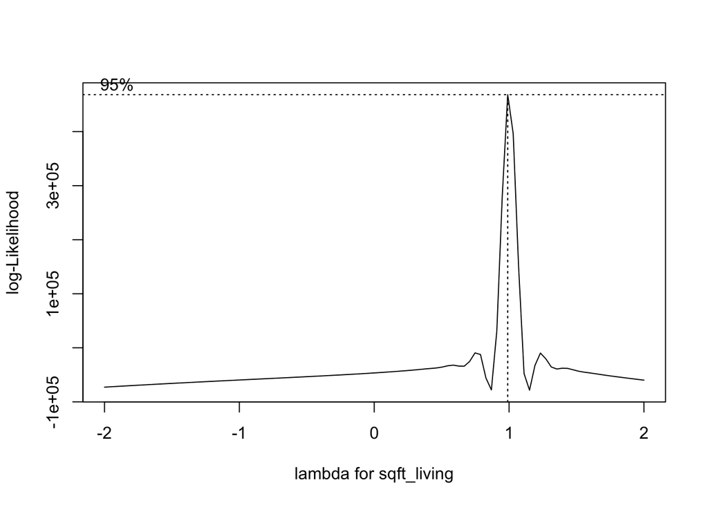

```r
m3 <- lm("sqft_living~.-price+log(price)", data = kc_train_data)
boxcox(m3,xlab = "lambda for sqft_living")
```

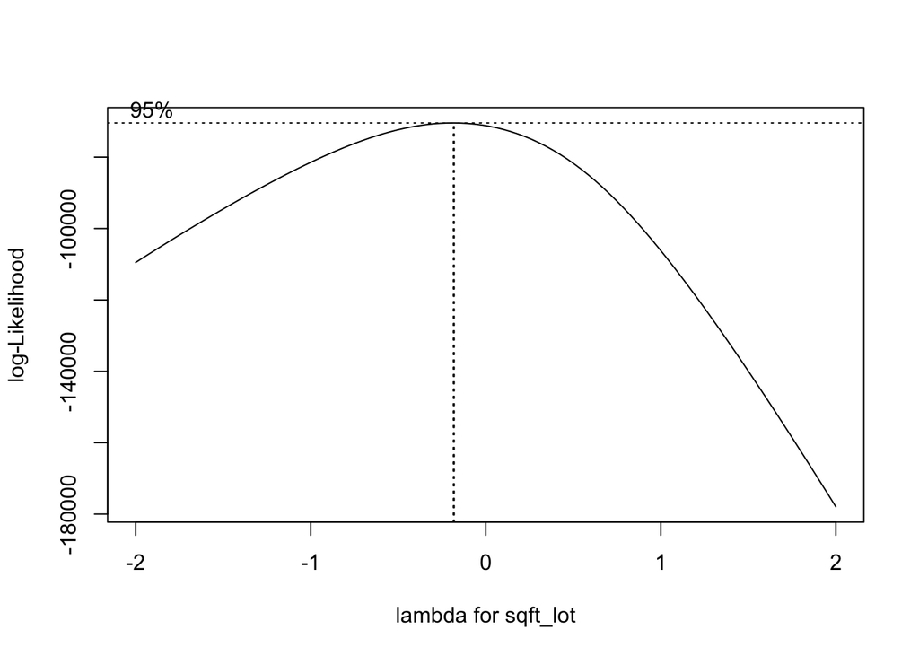

```r
m3 <- lm("sqft_lot~.-price+log(price)", data = kc_train_data)
boxcox(m3,xlab = "lambda for sqft_lot")
```

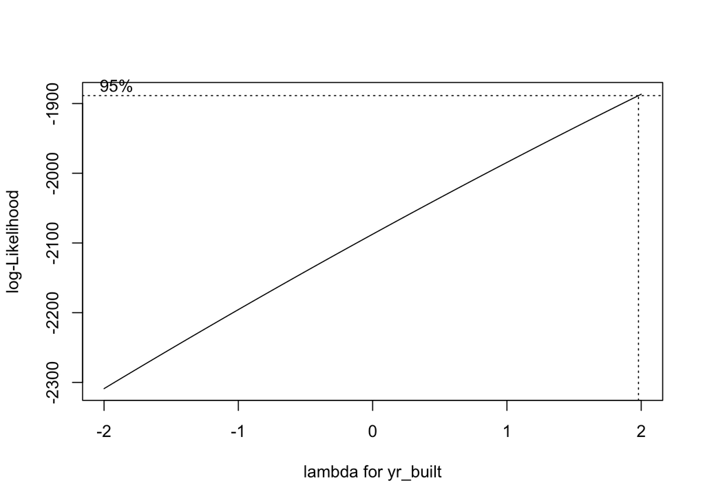

```r
m3 <- lm("yr_built~.-price+log(price)", data = kc_train_data)
boxcox(m3,xlab = "lambda for yr_built")
```

```r
add_model_pred_trans = lm(price ~ . - sqft_lot - sqft_living + log(sqft_lot) + log(sqft_living), data = kc_train_data)

summary(add_model_pred_trans)$adj.r.squared
```

```
## [1] 0.8253618
```

```r
summary(full_add_model)$adj.r.squared
```

```
## [1] 0.8076527
```

```r
calc_loocv_rmse(add_model_pred_trans)
```

```
## [1] 152102.2
```

```r
calc_loocv_rmse(full_add_model)
```

```
## [1] 159487.6
```

As seen above, the model with the transformations has a higher adjusted $R^2$ and a lower LOOCV-RMSE.

### Influential Observations

Before we proceed, we must check if there are influential observations that should be ignored.

```r
sum(cooks.distance(full_add_model) > 4 / length(cooks.distance(full_add_model)))
```

```
## [1] 751
```

We can see that there are 751 influential points in the model.

Let’s try removing them and building a new model then checking the model’s performance to see if it was warranted.

```r
obs_to_remove_idx = which(cooks.distance(full_add_model) > 4 / length(cooks.distance(full_add_model)))
kc_train_data_infl_rmvd = kc_train_data[-obs_to_remove_idx,]

full_add_model_infl_rmvd = lm(price ~ ., data = kc_train_data_infl_rmvd)

summary(full_add_model_infl_rmvd)$adj.r.squared
```

```
## [1] 0.8798378
```

```r
summary(full_add_model)$adj.r.squared
```

```
## [1] 0.8076527
```

```r
calc_loocv_rmse(full_add_model)
```

```
## [1] 159487.6
```

```r
calc_loocv_rmse(full_add_model_infl_rmvd)
```

```
## [1] 92854.29
```

As seen above, the full new additive model without the influential observations has a adjusted $R^2$ of 0.8798378 which is better than the full additive model which has a value of 0.8076527.

The LOOCV-RMSE score for the model without influential observations, 9.2854292^{4} is also much lower than the full model, 1.5948757^{5}. So we will proceed with the data without the influential points.

### Model Assumptions

Let’s take a look at the diagnostics for this model. First we defined a helper function to help us plot the fitted vs residuals and QQ plots.

```r
diagnostics = function(model, pcol = "grey", lcol = "dodgerblue", alpha = 0.05, plotit = TRUE, testit = TRUE){

  if(plotit) {
    plot(fitted(model), resid(model), col = pcol, pch = 20,
         xlab = "Fitted", ylab = "Residuals", main = "Fitted vs Residuals")
    abline(h = 0, col = lcol, lwd = 2)

    qqnorm(resid(model), main = "Normal Q-Q Plot", col = pcol)
    qqline(resid(model), col = lcol, lwd = 2)
  }

  if(testit){
    p_val = shapiro.test(resid(model))$p.value
    decision = ifelse(p_val < alpha, "Reject","Fail to Reject")
    list(p_val = p_val, decision = decision)
  }
}
```

Now let’s check the assumptions of the full additive model.

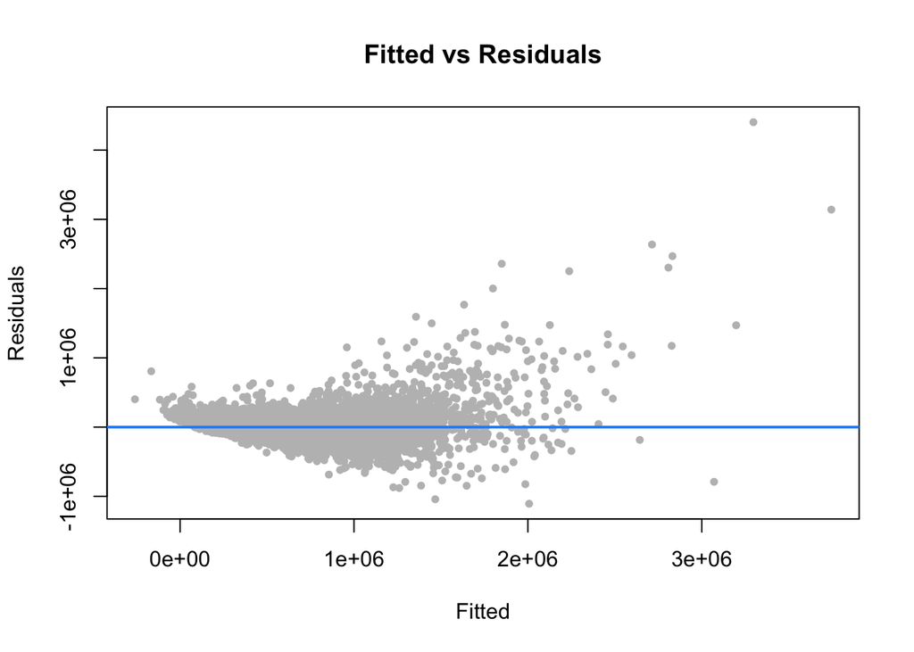

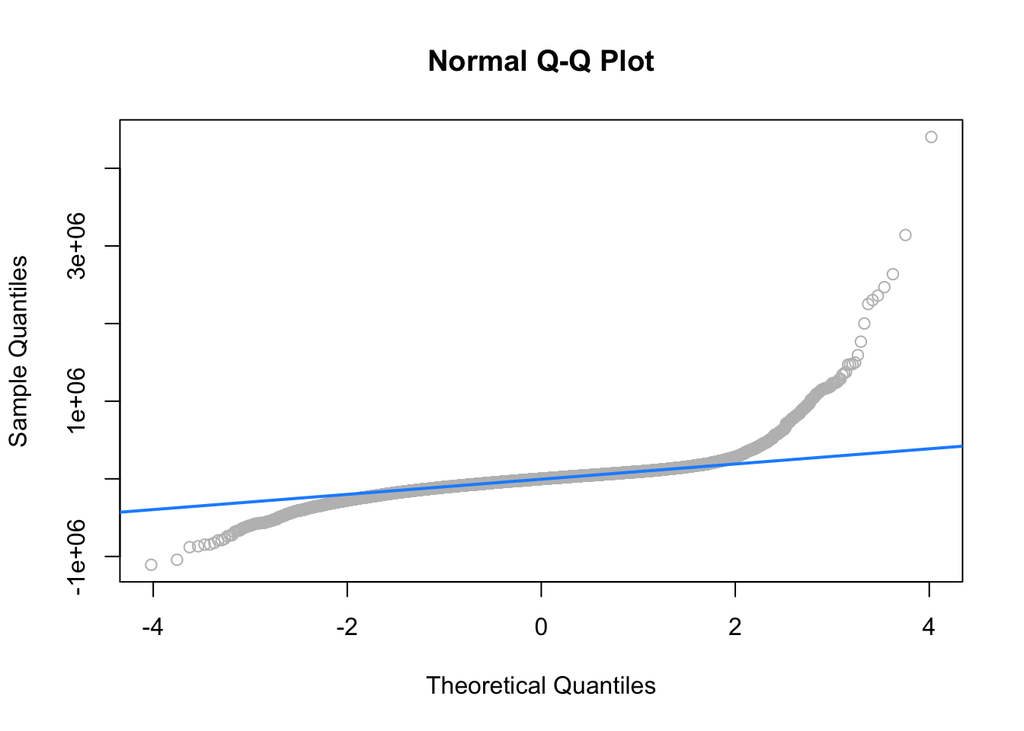

```r
diagnostics(full_add_model, testit = FALSE)
```

We can see that both assumptions of equal variance and normality don’t hold.

Let’s try the transforming the response.

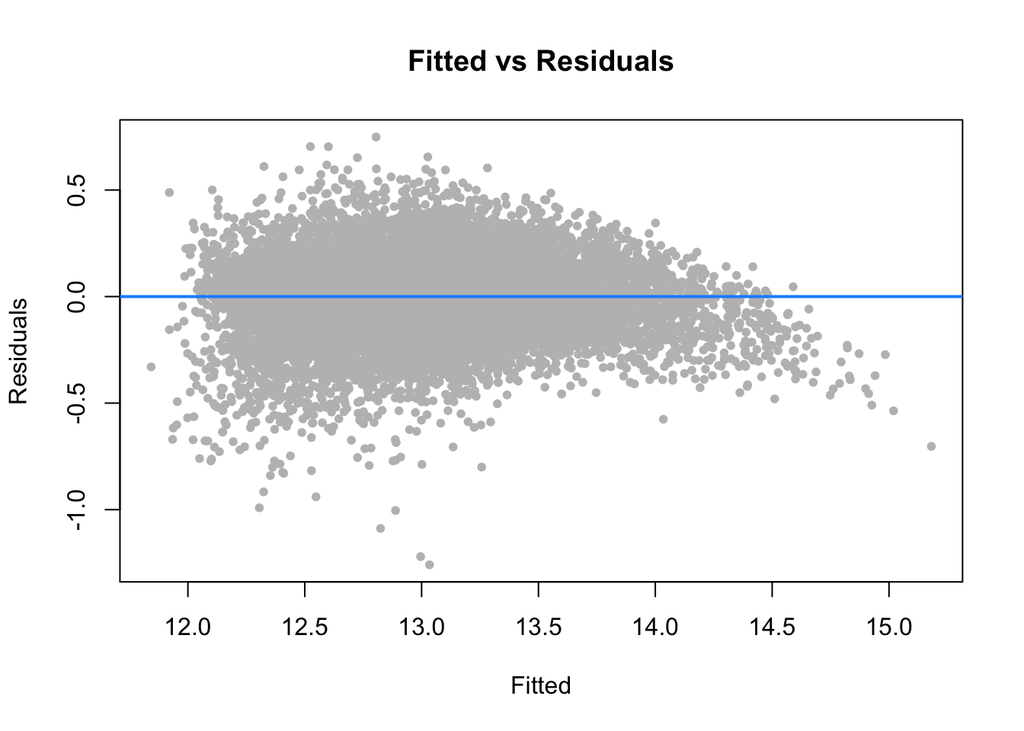

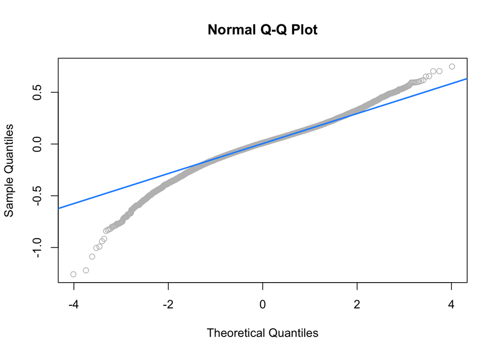

```r
full_add_log_model = lm(log(price) ~ ., data = kc_train_data_infl_rmvd)

diagnostics(full_add_log_model, testit = FALSE)
```

The graphs look much better. Transforming the response is the way to go.

### Putting it all together

Let’s create a model that both transforms the response and the selected predictors, with no influential observations.

```r
add_log = lm(log(price) ~ . - sqft_lot - sqft_living + log(sqft_lot) + log(sqft_living), data = kc_train_data_infl_rmvd)

summary(add_log)$adj.r.squared
```

```
## [1] 0.885397
```

Let’s do a AIC backwards each to see if we can decrease the number of predictors even further.

```r
selected_add_log = step(add_log, trace=FALSE)

summary(selected_add_log)$adj.r.squared
```

```
## [1] 0.8854011
```

This selected model does not seem to do much better than the full log model.

## Results

Comparing all the models we have tried so far:

```r
table = data.frame(Model = c("Full Additive", "Add w/o Collinear Preds", "Full Add Log Res/Pred", "Selected Add Log Res/Pred"),
         Adj_R_Squared = c(summary(full_add_model)$adj.r.squared,
                           summary(selected_no_coll)$adj.r.squared,
                           summary(add_log)$adj.r.square,
                           summary(selected_add_log)$adj.r.square
                          ),

         Train_RMSE = c(sqrt(mean((kc_train_data$price - predict(full_add_model, kc_train_data)) ^ 2)),
                        sqrt(mean((kc_train_data$price - predict(selected_no_coll, kc_train_data)) ^ 2)),
                        sqrt(mean((kc_train_data_infl_rmvd$price - exp(predict(add_log, kc_train_data_infl_rmvd))) ^ 2)),
                        sqrt(mean((kc_train_data_infl_rmvd$price - exp(predict(selected_add_log, kc_train_data_infl_rmvd))) ^ 2))
                      ),

         Test_RMSE = c(sqrt(mean((kc_test_data$price - predict(full_add_model, kc_test_data)) ^ 2)),
                        sqrt(mean((kc_test_data$price - predict(selected_no_coll, kc_test_data)) ^ 2)),
                        sqrt(mean((kc_test_data$price - exp(predict(add_log, kc_test_data))) ^ 2)),
                        sqrt(mean((kc_test_data$price - exp(predict(selected_add_log, kc_test_data))) ^ 2))
                      ),

         Number_Predictors = c(length(coef(full_add_model)) - 1,
                               length(coef(selected_no_coll)) - 1,
                               length(coef(add_log)) - 1,
                               length(coef(selected_add_log)) - 1)
         )

kable(table,caption="Model Selection Table")
```

Model Selection Table

| Model | Adj_R_Squared | Train_RMSE | Test_RMSE | Number_Predictors |
| --- | --- | --- | --- | --- |
| Full Additive | 0.8076527 | 158005.09 | 172860.9 | 86 |
| Add w/o Collinear Preds | 0.7574447 | 177463.52 | 195486.6 | 79 |
| Full Add Log Res/Pred | 0.8853970 | 86315.67 | 134387.3 | 86 |
| Selected Add Log Res/Pred | 0.8854011 | 86305.09 | 134514.6 | 84 |

## Discussion

In comparing the various model across the various dimensions such as adjusted R squared, train RMSE, test RMSE, as well as number of predictors, our group determined that the selected add log res/pred model performs the best with the highest adjusted R_squared value since the goal of this project is to predict house prices no restriction/limitation on memory or performance. At first glance, it might be harder to interpret due to the number of predictors, but it appears performs better than the full additive model without overfitting, although our experimentation with transformations on non-normal dependent variables into a normal shape became easier using box-cox transformation and this is also the model without any highly influential observations. In addition to the current result, we could further experiment with featuring engineering neighborhood data with the latitude and longitude predictors to further categorize the house location and determine whether it belongs to an urban area or rural area to aid with predictions. Another route for exploration which expands beyond the scope of the goals of this project is to leverage the benefits of k-fold cross-validation, the average testing accuracy as a benchmark, as well as play with various training/test set split to help derive the optimal set of results.

## Appendix

### Interactions

We did not include the interactions explorations because we did not see any benefits plus it took too long to calculate.

One other thing to try is interactions. Let’s perform a AIC backwards search from a model with 2 ways interactions to see what happens. Let’s use the model without the collinear variables as the base since it is smaller it will be easier to compute the interactions.

```r
full_int_model = lm(price ~ (. - sqft_living - sqft_above - yr_built)^2, data = kc_train_data)
selected_int_model = step(full_int_model, trace = FALSE)
```

Let’s check the model summary to see what all got added.

```r
summary(selected_int_model)
```

```r
anova(full_add_model, selected_int_model)[2, "Pr(>F)"] < 0.05

table <- data.frame(Model = c("Interaction","Full Add"),
         Adj_R_Squared = c(summary(selected_int_model)$adj.r.squared,summary(full_add_model)$adj.r.squared),
         Loocv_RMSE = c(calc_loocv_rmse(selected_int_model),calc_loocv_rmse(full_add_model)),
         Number_Predictors = c(length(coef(selected_int_model)) - 1, length(coef(full_add_model)) - 1))
kable(table,caption="Model Selection Table")
```

### Team members

- Moore, Stefani- stefani6@illinois.edu
- Chen, Yun Ying - yyc2@illinois.edu
- Nimashakavi, Kiranmayee - kn13@illinois.edu
- Ramanan, Gowri Shankar - gsr2@illinois.edu